# Midterm Report Part 2

## **Contributors:**

> William Loving (wfl9zy) James Sweat (jes9hd)

## **Goals:**

> - Find out if higher salary jobs tend to be rated more highly than lower salary.
> - Find out where Jobs are offered and see if some jobs are location specific.
> - Find out which Job roles have the highest ratings and what kinds of jobs they are.
> - Find out which Job roles have the highest salaries and what kinds of jobs they are.

# **Part 2: Software Engineering Positions in India:**

> - The data is vast so visualizations must be poignant and intentional with the correlations we hope to explore.
> - We’ll begin by loading the data and making small transformations for ease of use.

```r
library(readr)
library(dplyr)
library(ggplot2)
library(plotly)
```

# **Load Data:**

```r
data <- read_csv("../data/india-data/Salary_Dataset_with_Extra_Features.csv")
```

```r
head(data)
```

```
## # A tibble: 6 × 8
##   Rating `Company Name`          `Job Title` Salary `Salaries Reported` Location
##    <dbl> <chr>                   <chr>        <dbl>               <dbl> <chr>
## 1    3.8 Sasken                  Android De…    4e5                   3 Bangalo…
## 2    4.5 Advanced Millennium Te… Android De…    4e5                   3 Bangalo…
## 3    4   Unacademy               Android De…    1e6                   3 Bangalo…
## 4    3.8 SnapBizz Cloudtech      Android De…    3e5                   3 Bangalo…
## 5    4.4 Appoids Tech Solutions  Android De…    6e5                   3 Bangalo…
## 6    4.2 Freelancer              Android De…    1e5                   3 Bangalo…
## # ℹ 2 more variables: `Employment Status` <chr>, `Job Roles` <chr>
```

# **Make Some Transformations for Ease of Understanding:**

```r
#Remove the one outlier
threshold <- 9000000

data_filtered <- data%>%
  filter(Salary < threshold)

data_filtered$Location <- as.factor(data_filtered$Location)
data_filtered$`Employment Status` <- as.factor(data_filtered$`Employment Status`)
```

# **Create Visuals:**

# Plot 1:

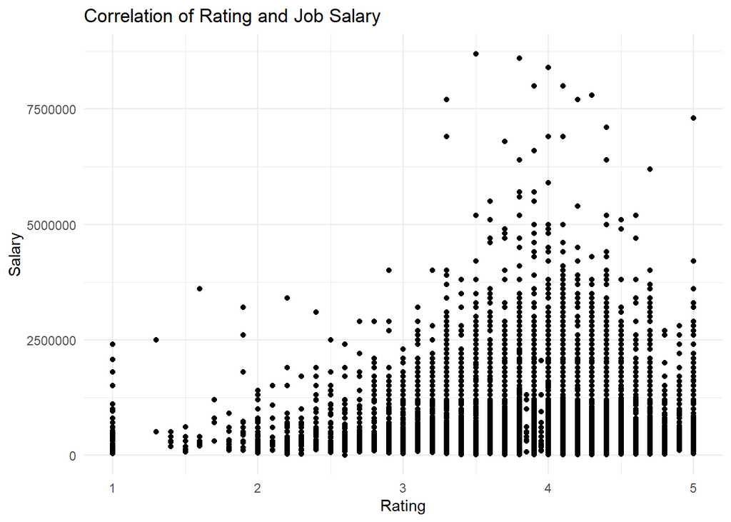

# Plot 2:

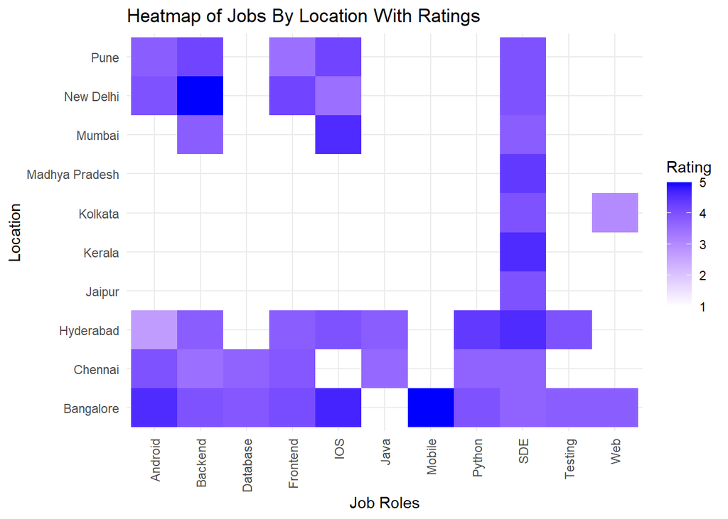

> - This plot allows us to find out where certain jobs are offered and how those jobs are rated by the employees. You can see where certain jobs are not offered as well as where the highest rated jobs can be found. If you want a great Mobile development experience, go to Bangalore, for example.

# Plot 3:

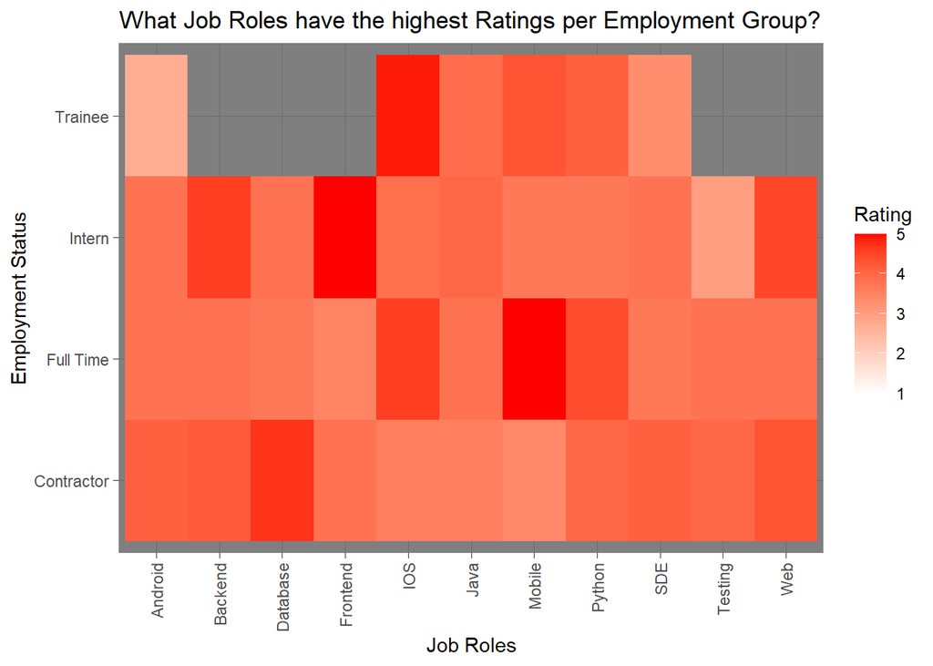

# Plot 4:

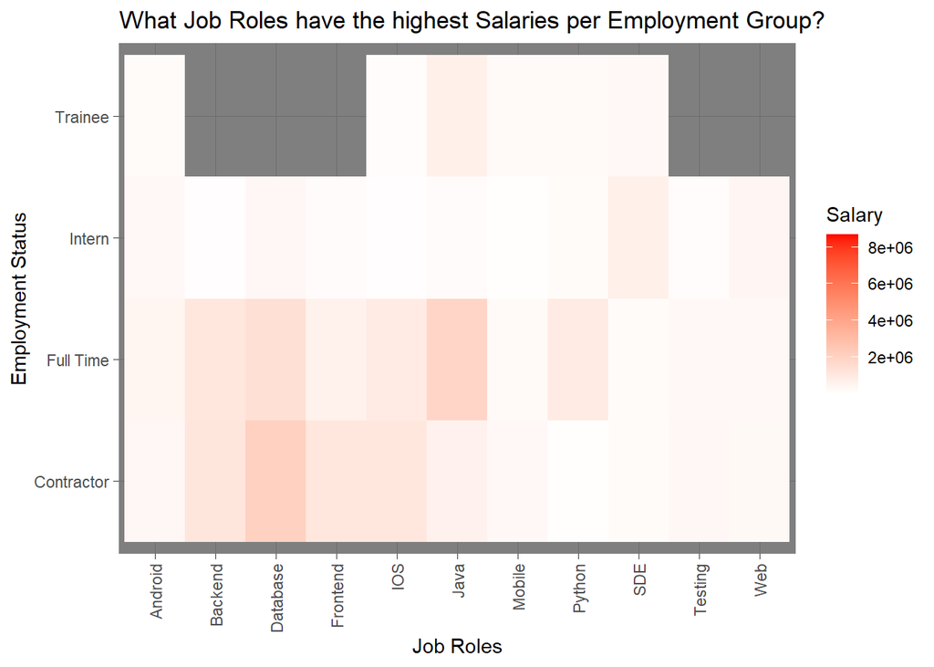

> - This plot is virtually identical to the above, but now we are filling by the salary instead of the rating to allow for more granular decision making, do you want more pay or higher rating?